# Ethiopian Public Health Institute, Public Health Emergency Management

Mesfin K

2026-09-22

- The campaigne coveres only 7 region out of the 14 regional state

# Geographic vaccination coverage

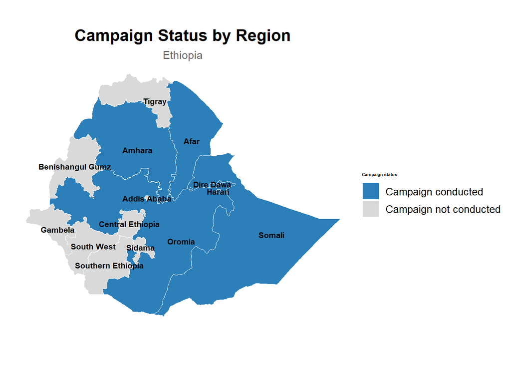

# Integrated nOPV2 Campaign Administrative performance by region

- The overall regional performance exceeded targets across all areas, successfully fulfilling the minimum national target of 95% campaign success.

## Table 1 regional performance

| Region | Num of Zones | Num of Woredas | Target | Performance | Coverage Proportion |
| --- | --- | --- | --- | --- | --- |
| Afar | 6 | 52 | 349,073 | 350,932 | 100.5326% |
| Amhara | 8 | 58 | 3,520,897 | 3,591,778 | 102.0132% |
| Dire Dawa | 1 | 9 | 97,364 | 109,002 | 111.9531% |
| Harari | 1 | 9 | 70,869 | 75,771 | 106.9170% |
| Oromia | 10 | 83 | 3,549,090 | 3,724,272 | 104.9360% |
| Somali | 4 | 48 | 662,018 | 673,034 | 101.6640% |
| South Ethiopia | 1 | 13 | 258,568 | 277,050 | 107.1478% |
| Total | 31 | 272 | 8,507,879 | 8,801,839 | 103.4552% |

# nOPV2 Vaccination status by age group

- Majority of children had received at least one dose of polio vaccine before the campaign.
- Children identified had not been reached through routine immunization Potential immunity gap: These children may have limited or no prior immunity against polio virus.
- The campaign can identify and vaccinate children who are missed by routine immunization.
- Link children identified as missed by routine immunization to routine vaccination services.
- The focus should not only be on the number vaccinated, but also on identifying and closing immunity gaps among previously un reached children.

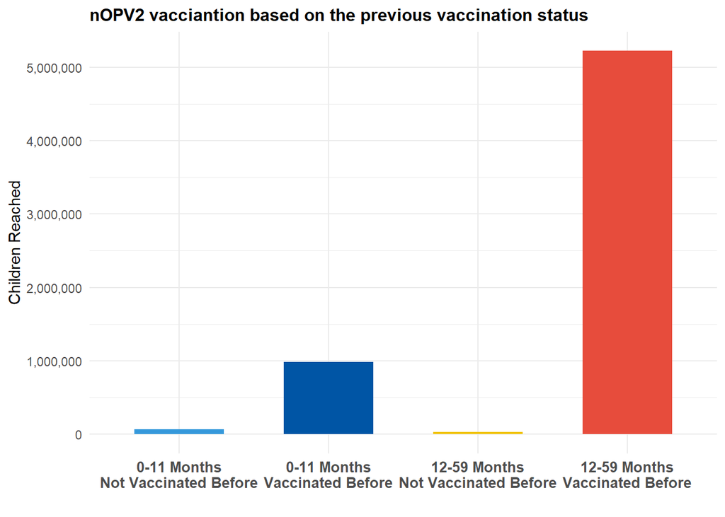

# Vaccine utilization

- Oromia and Amhara region handled the highest volumes of nOPV2 vaccines, dominating “Received,” “Used,” and “Partially Used” counts.
- Regions such as Harari, Dire Dawa, and South Ethiopia maintain very low counts across all seven metrics. This indicates limited campaign scale in these specific areas.

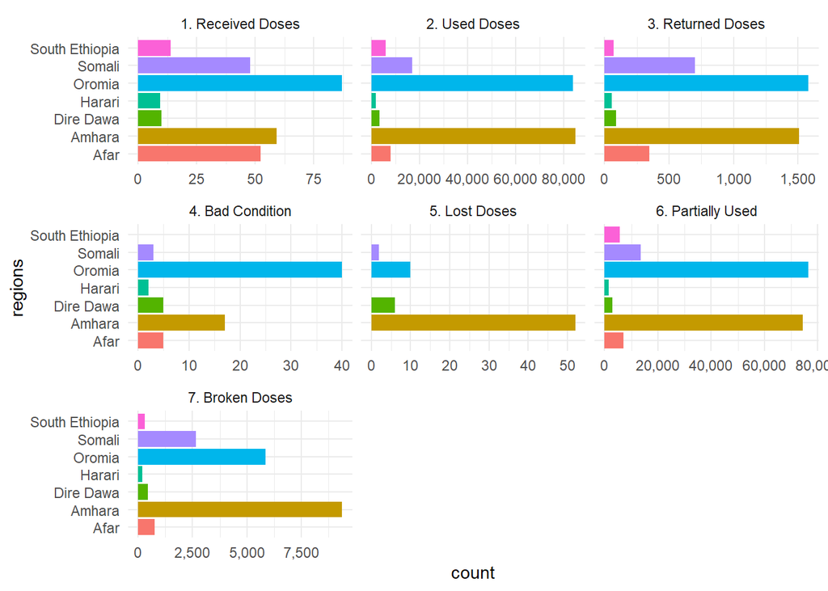